# Human activity recognition: weight lifting

Joan Verdu, Practical Machine Learning, Data Science Specialization, Coursera

Friday, August 22, 2014

This study is related to human activity recognition through personal activity devices. In this project, our goal was to use data from accelerometers on the belt, forearm, arm, and dumbell of 6 participants. They were asked to perform barbell lifts correctly and incorrectly in 5 different ways. More information is available from the website here: http://groupware.les.inf.puc-rio.br/har (see the section on the Weight Lifting Exercise Dataset).

# 1. Dataset

Data consists of 160 variables, including variable ‘classe’ which is the 5 types of lifts that should be predicted from the other variables. There are 19622 observations in the train dataset, and 20 observation in the test dataset.

```r
train<-read.csv("pml-training.csv",na.strings=c("NA","","#DIV/0!"))
test<-read.csv("pml-testing.csv",na.strings=c("NA","","#DIV/0!"))
```

# 2. Exploratory analysis

## 2.1 Data cleaning

We first explore all variables to eliminate near zero variance variables, and also variables highly correlated to other ones (r>0.9). We filled NA values using k-nearest-neighbour method.

```r
# check for empty variables
prop.na<-rep(0,ncol(train))
for (i in 1:ncol(train)){
    prop.na[i]<-sum(is.na(train[i]))/nrow(train[i])
}
## 100 variables are empty or almost empty, and should be disregarded from the analysis
## we focus on 60 remaing variables, includin the index (X) and the output (classe)
index<-prop.na<0.2
trainfilt<-train[index]
testfilt<-test[index] #same with test data
```

```r
## Fill na values with KnnImpute of preProcess function
class<-as.vector(sapply(trainfilt,class))
trainfilt2<-trainfilt
testfilt2<-testfilt
for (i in 1:ncol(trainfilt)){
    if (class[i]=="numeric") {
        preobj<-preProcess(trainfilt[i],method="knnImpute")
        trainfilt2[i]<-predict(preobj,trainfilt[i])
        testfilt2[i]<- predict(preobj,testfilt[i])
    }
}
rm(train,test,trainfilt,testfilt)

##Check for 'near zero' covariates
indexnzero<-nearZeroVar(trainfilt2)
trainfilt2<-trainfilt2[-indexnzero]
testfilt2<-testfilt2[-indexnzero]
## eliminate index variable X, user, num_window, and time variables
trainfilt2<-trainfilt2[-c(1:6)]
testfilt2<-testfilt2[-c(1:6)]

#check for highly correlated variables
corel<-cor(trainfilt2[1:52])
corel[upper.tri(corel)]<-NA # remove upper triangle matrix values
diag(corel)<-NA #remove diagonal values
checkcor<-which( abs(corel) > 0.9, arr.ind=T )
checkcor2<-data.frame(checkcor)
checkcor2$rowname<-colnames(corel)[checkcor2$row]
checkcor2$colname<-colnames(corel)[checkcor2$col]
print(checkcor2[,3:4])

trainfilt2<-trainfilt2[-c(4,8:10,18,31,33)]
testfilt2<-testfilt2[-c(4,8:10,18,31,33)]
```

Variables **total_accel_belt, accel_belt_y**, and **accel_belt_z** (highly correlated with roll belt) and accel_belt_x (correlated with pitch belt) were removed. Also **gyros_arm_x** (correlated with ‘y’), **gyros_dumbbell_x** and **gyros_dumbbell_z** (correlated with gyros_forearm_z) were removed.

This is the list of variable combination with correlation greater than 0.9 in absolute value.

```
##             rowname          colname
## 1  total_accel_belt        roll_belt
## 2      accel_belt_y        roll_belt
## 3      accel_belt_z        roll_belt
## 4      accel_belt_x       pitch_belt
## 5      accel_belt_y total_accel_belt
## 6      accel_belt_z total_accel_belt
## 7      accel_belt_z     accel_belt_y
## 8       gyros_arm_y      gyros_arm_x
## 9  gyros_dumbbell_z gyros_dumbbell_x
## 10  gyros_forearm_z gyros_dumbbell_x
## 11  gyros_forearm_z gyros_dumbbell_z
```

Next figure shows correlation values among 52 variables available so far, and the 11 pais of variables (in red) whose correlation is above 0.9 in absolute value.

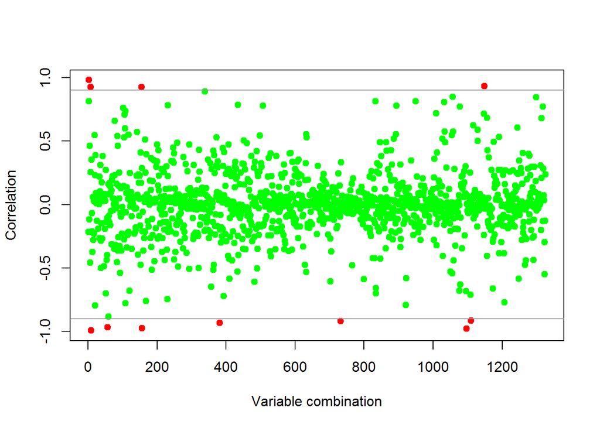

## 2.2 Variable standarization

We standarize numeric variables to mean=0 and std.dev=1.

```r
preObj<-preProcess(trainfilt2[1:45],method=c("center","scale"))
trainfilt2[1:45]<-predict(preObj,trainfilt2[1:45])
testfilt2[1:45]<-predict(preObj,testfilt2[1:45]) # also with test data
```

## 2.3 Model selection

We split the cleaned train data into a subtrain and a subtest data, in order to run several models and choose the most accurate one.

```r
## data partition to select model
subtrain<-createDataPartition(y=trainfilt2$classe,p=0.6,list=FALSE)
trainstrain<-trainfilt2[subtrain,]
trainstest<-trainfilt2[-subtrain,]
```

Using subtrain data we built four types of models (tree, LDA, QDA and random forests), and check its accuracy by predicting the subtest data, using `caret` package.

```r
set.seed(10)
# Tree
model1<-train(classe~.,data=trainstrain,method="rpart")
pred1<-predict(model1,newdata=trainstest)
res1<-confusionMatrix(pred1,trainstest$classe)

# LDA
model2 <- train(classe~.,data=trainstrain,method="lda")
pred2<-predict(model2,newdata=trainstest)
res2<-confusionMatrix(pred2,trainstest$classe)

#  QDA
model3 <- train(classe~.,data=trainstrain,method="qda")
pred3<-predict(model3,newdata=trainstest)
res3<-confusionMatrix(pred3,trainstest$classe)

# random forest
model4<-train(classe~.,data=trainstrain,method="rf",trControl=trainControl(number=10))
pred4<-predict(model4,newdata=trainstest)
res4<-confusionMatrix(pred4,trainstest$classe)
```

The overall accuracy and accuracy by activity class is shown in this figure.

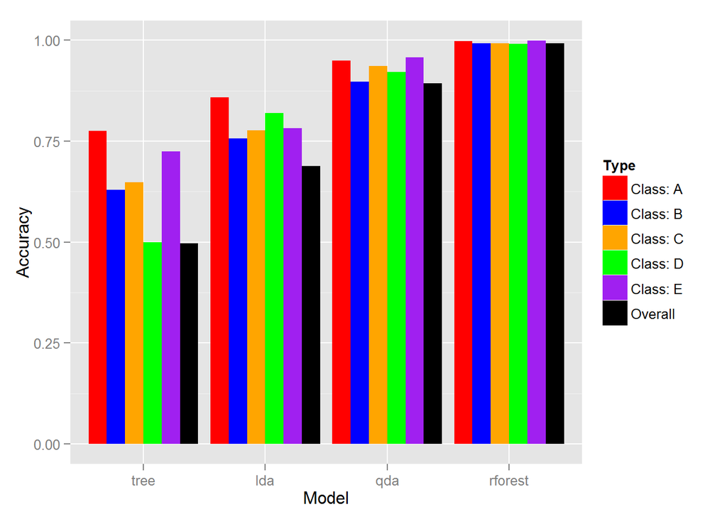

**Random forest** showed to be the most accurate model, reaching 99% of accuracy.

## 2.4 Final variable selection

One the model is chosen, we try to reduce the number of dependent variables without loosing accuracy, in order to optimize its application. We use `varImp()` function from `caret` package.

```r
vars<-varImp(model4)$importance
vars$names<-rownames(vars)
vars<-vars[order(vars[,1],decreasing=T),]
names<-vars$names[vars[,1]>8]
names2<-c(names,"classe") # add output
```

```r
traincheck<-subset(trainstrain, select=names2)
testcheck<-subset(trainstest, select=names2)
model4bis<-train(classe~.,data=traincheck,method="rf",trControl=trainControl(number=10))
pred4bis<-predict(model4bis,newdata=testcheck)
res4bis<-confusionMatrix(pred4bis,testcheck$classe)
```

Overall accuracy has drop only 0.2%, and still above 99%.

```
## [1] "Complete rf model, accuracy: 99.21 %"
```

```
## [1] "Reduced rf model, accuracy: 99.01 %"
```

We decide to built our final model using only these 21 variables, namely (ordered by importance):

```
##  [1] "roll_belt"            "pitch_forearm"        "yaw_belt"
##  [4] "magnet_dumbbell_z"    "pitch_belt"           "magnet_dumbbell_y"
##  [7] "roll_forearm"         "accel_dumbbell_y"     "magnet_belt_y"
## [10] "roll_dumbbell"        "magnet_dumbbell_x"    "accel_forearm_x"
## [13] "magnet_belt_z"        "accel_dumbbell_z"     "magnet_forearm_z"
## [16] "total_accel_dumbbell" "gyros_belt_z"         "magnet_belt_x"
## [19] "yaw_arm"              "accel_forearm_z"      "gyros_dumbbell_y"
```

# 3. Final model

Our final model is a **random forest**, using the 21 variables previously selected, in order to estimate ‘classe’ variable (5 types of barbelt lifts). First we subset the train and test datasets to select 21 variables (plus variable ‘classe’). Then we build a random forest model, and predict ‘classe’ values for our test dataset. This is the code and the final output.

```r
traindef<-subset(trainfilt2, select=names2)
testdef<-subset(testfilt2, select=names)

modeldef<-train(classe~.,data=traindef,method="rf",trControl=trainControl(number=10))
preddef<-predict(modeldef,newdata=testdef)
outdef<-confusionMatrix(modeldef)$table
modeldef$finalModel
```

```
##
## Call:
##  randomForest(x = x, y = y, mtry = param$mtry)
##                Type of random forest: classification
##                      Number of trees: 500
## No. of variables tried at each split: 2
##
##         OOB estimate of  error rate: 0.57%
## Confusion matrix:
##      A    B    C    D    E class.error
## A 5574    5    0    0    1    0.001075
## B   21 3759   16    1    0    0.010008
## C    0   17 3396    9    0    0.007598
## D    0    0   25 3188    3    0.008706
## E    0    0    4    9 3594    0.003604
```

```r
modeldef
```

```
## Random Forest
##
## 19622 samples
##    21 predictors
##     5 classes: 'A', 'B', 'C', 'D', 'E'
##
## No pre-processing
## Resampling: Bootstrapped (10 reps)
##
## Summary of sample sizes: 19622, 19622, 19622, 19622, 19622, 19622, ...
##
## Resampling results across tuning parameters:
##
##   mtry  Accuracy  Kappa  Accuracy SD  Kappa SD
##   2     1         1      0.001        0.001
##   10    1         1      0.001        0.002
##   20    1         1      0.003        0.004
##
## Accuracy was used to select the optimal model using  the largest value.
## The final value used for the model was mtry = 2.
```

Random forests internally uses boostrap sample to construct each tree and estimates the OOB (out of bag) error, 0.57% in our model. This is an estimate of **out of sample error**, and thus there is no further need of cross validation, more details in http://www.stat.berkeley.edu/~breiman/RandomForests/cc_home.htm#ooberr Finalmodel consists on 500 trees, with 2 variables tried at each split. Classification error ranges from 1% (class B) to 0.1% (class A).